# Predicting Outpatient Consultation Duration

A Machine Learning Pipeline for the Hangu Outpatient Oncology Clinic, in Support of Time-Driven Activity-Based Costing

Author

Ariana Butina

Published

July 2, 2026

## 1 Introduction and Motivation

This report documents a complete, reproducible machine learning pipeline for predicting outpatient consultation duration at the Hangu outpatient oncology clinic. Two models are built from the same historical data: a **classifier** that flags whether a consultation will be *long* relative to the clinic’s own history, and a **regressor** that predicts the consultation’s duration directly, in minutes.

The motivation is applied rather than purely academic. This project supports a master’s thesis at the University of Ljubljana School of Economics and Business applying the **Time-Driven Activity-Based Costing (TDABC)** framework (Kaplan and Anderson 2004) to outpatient services. TDABC is built on two inputs for every activity: a *capacity cost rate* and the *time required to perform the activity*. Consultation duration is exactly the second input — so a model that predicts it, and that is honest about how well it predicts it, is directly useful for estimating per-visit cost drivers and for evaluating whether routinely available scheduling variables (day of week, time of day, visit history, diagnosis flags) carry enough signal to inform capacity planning.

Every methodological choice below is made with two requirements in mind: **no data leakage** and **honest evaluation**. Where a modelling decision could look more impressive by cutting either corner, the less impressive, more honest choice was made instead, and is documented as such.

## 2 Dataset

The data is the **Hangu Open Data** outpatient consultation dataset (Feng et al. 2023, 2024), licensed CC BY-NC-SA 4.0. It contains **6,637 consultation records** from **2,429 unique patients** at a single clinic, collected across 2018–2019. Because many patients have repeat visits, the rows are *not* independent observations — a fact that shapes the train/test splitting and cross-validation strategy described in Section 6.

Each row records:

- `Visit.No` — the patient’s visit number at this clinic (1 = first visit)
- `Gender`, `M.Cancer`, `S.Cancer` — patient demographic and primary/secondary cancer flags
- `Month`, `DayOfWeek`, `AM_PM`, `WorkingDay` — scheduling context for the visit
- `Address` — patient’s home region (in the city / out of city / out of province)
- `ServTime` — the recorded consultation duration, in seconds (the source of both targets)

A small number of fields present in the raw file (`ID`, `Session`, `StartTime`, `PayTime`) are **not** used as predictors; the rationale for excluding each is given in Section 5.

## 3 Exploratory Data Analysis

The full exploratory analysis is available as a standalone, executed notebook (`notebooks/01_eda.ipynb`); the key findings that shaped every downstream decision are summarised here.

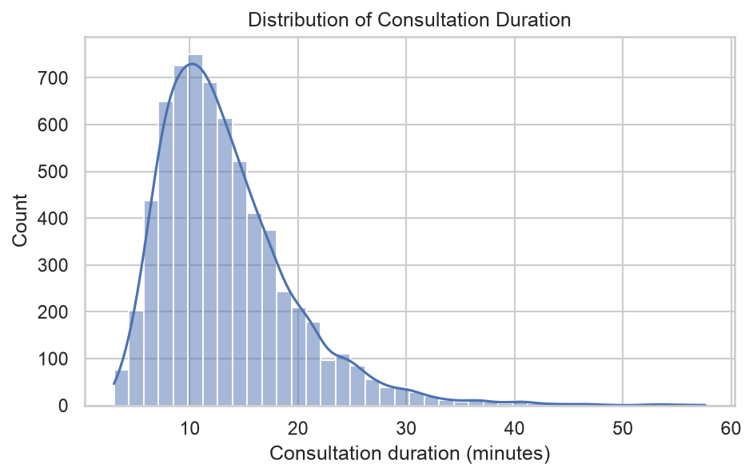

Figure 1: Consultation duration is right-skewed: most visits last 8-16 minutes, with a long tail out to nearly an hour.

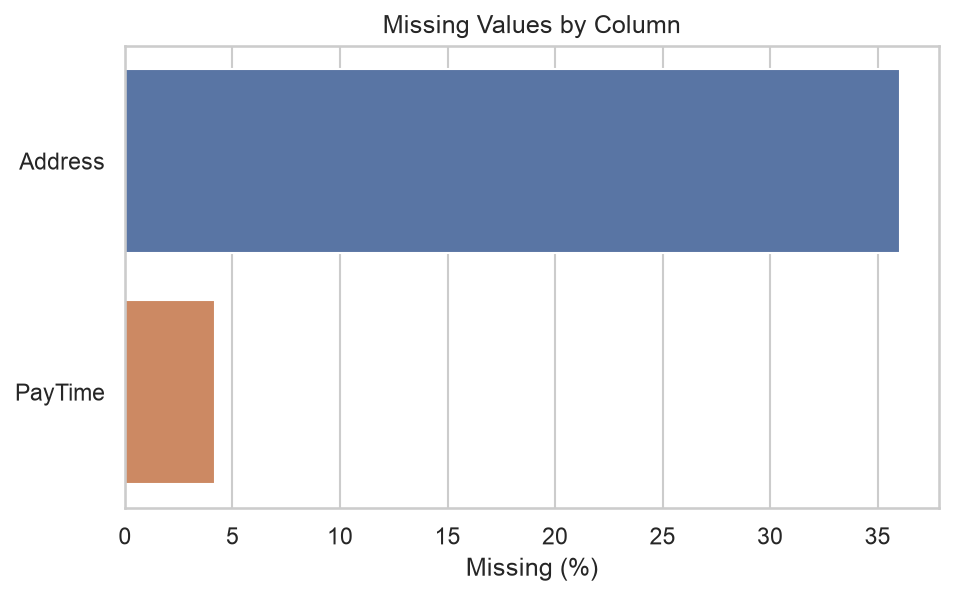

Figure 2: Missing values are concentrated in two columns: `Address` (~36%) and `PayTime` (~4%).

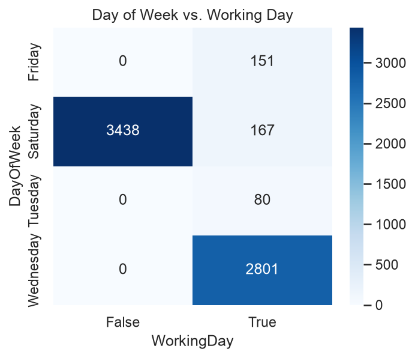

Figure 3: Day of week versus the WorkingDay flag. Saturday is normally non-working, but a subset of Saturdays are marked as working – a compensatory-holiday scheduling pattern, not noise.

Three findings mattered most:

1. **Repeat visits are common.** 1,192+ patients appear more than once in the data, so a plain random train/test split would let the same patient leak across both sets.
2. **`Address` missingness is likely informative, not random**, given its scale (over a third of rows) — treating it as its own category was preferred over imputation.
3. **`WorkingDay` is not redundant with `DayOfWeek`.** The clinic operates mainly Wednesday and Saturday; a subset of Saturdays are marked as working days, consistent with a compensatory-holiday scheduling pattern. This directly motivated one of the engineered features described next.

## 4 Data Cleaning and Feature Engineering

Every cleaning rule was a deliberate response to a finding above, not a generic default:

- **`Address`** missing values were filled with an explicit `"Unknown"` category rather than imputed, since missingness itself is plausibly meaningful.
- **`PayTime`/`StartTime`** were left untouched: cross-checking showed `PayTime − StartTime` does not reliably reconstruct `ServTime`, so these timestamps are unreliable and were never used to derive or validate the target.
- **Inconsistent `M.Cancer` flags across a patient’s repeat visits** (33 patients) were *not* forcibly reconciled — a diagnosis can legitimately change between visits, so this is reported for transparency rather than corrected.
- **`ServTime` outliers** (high-duration visits) were kept. A long consultation is a plausible clinical outcome, not a data error.

Three features were engineered, each mapping directly to a requirement or an EDA finding:

| Feature | Definition | Rationale |
| --- | --- | --- |
| `IsRepeatVisit` | `Visit.No > 1` | Captures first-time vs. returning patients |
| `IsPublicHolidayMakeup` | `WorkingDay` true on a normally non-working Saturday | Operationalises the “public holiday” scheduling signal found in EDA |
| `HasCancerDiagnosis` | `M.Cancer OR S.Cancer` | `S.Cancer` alone is rare (~1%) and too sparse to be a useful standalone predictor |

## 5 Feature Selection

The final predictor set is identical for both tasks (12 columns): `Visit.No`, `WorkingDay`, `M.Cancer`, `S.Cancer`, `IsRepeatVisit`, `IsPublicHolidayMakeup`, `HasCancerDiagnosis`, `Month`, `DayOfWeek`, `AM_PM`, `Gender`, `Address`.

The following columns are deliberately excluded, with reasons:

[output not shown]

## 6 Methodology

**Targets.** The regression target is `ServTime` converted to minutes. The classification target, `IsLongConsultation`, is defined by a **fixed threshold: the dataset-wide median duration (12.08 minutes)**, computed once from the full historical population and frozen as a business-rule constant — analogous to a fixed clinical cutoff (e.g. “BMI > 30 is obese”). This is a label-*definition* choice, not a fitted preprocessing statistic, so deriving it from the full population does not leak information across the train/test split. It also yields a close to balanced label (49.8% positive), which keeps classification metrics meaningful.

**Preprocessing.** A single `ColumnTransformer` is shared by both tasks: median imputation and standard scaling for the one numeric feature; most-frequent imputation for boolean flags; most-frequent imputation and one-hot encoding (with `handle_unknown="ignore"`) for categorical features. It is always fit on the training fold only.

**Splitting.** Because rows are grouped by patient, both the train/test split and every cross-validation fold use `StratifiedGroupKFold`, grouped by patient `ID` and stratified by `IsLongConsultation`. This guarantees no patient’s visits are ever split across train and validation/test. The held-out test set is **5,309 train / 1,328 test rows** (≈80/20), with near-identical class balance on both sides (49.8% / 49.8%).

**Model selection.** A full model ladder was compared per task via `RandomizedSearchCV` over the group-aware cross-validation, covering four categories: a naive `DummyClassifier`/`DummyRegressor` baseline; a linear model (`LogisticRegression`/`Ridge`); a single `DecisionTreeClassifier`/`Regressor`; and two ensembles, `RandomForestClassifier`/`Regressor` and `XGBClassifier`/`Regressor`. All estimators use a fixed random seed (`random_state=42`). The dummy baseline is never a selection candidate in any meaningful sense — it exists so every leaderboard below shows exactly how much the tuned models beat “guess from the label distribution alone.” The decision tree is also compared against an *untuned*, depth-unconstrained version of itself (`decision_tree_unconstrained`) purely to make overfitting visible — see the **Overfitting Check** in each results section below.

**Honest evaluation.** The selected model per task was refit once on the full training set and scored **exactly once** on the held-out test set. Those numbers — reported below — were never fed back into further tuning. The *same* held-out test set is also used to build a full leaderboard across every candidate in the ladder (including `dummy`), so the report shows both the single deployed model’s metrics and how every alternative would have scored, not just the winner.

## 7 Classification Results: Long vs. Short Consultation

**Model selection (cross-validated on the training set only):**

Table 1

|  | Model | CV ROC-AUC |
| --- | --- | --- |
| 0 | Dummy | 0.5000 |
| 1 | Decision Tree | 0.6348 |
| 2 | Logistic Regression | 0.6381 |
| 3 | Xgboost | 0.6389 |
| 4 | Random Forest | 0.6408 |

Random Forest was selected, narrowly outperforming `logistic_regression` and `xgboost` — the three land within about 0.003 ROC-AUC of each other, suggesting the ceiling on predictive signal from this feature set is fairly firm regardless of model family. The single `decision_tree` trails a little further behind (0.635 CV ROC-AUC) — a lone tree is simply a weaker learner than an ensemble of them. The naive `dummy` baseline (predicting from the label distribution alone, no features) scores exactly 0.5 CV ROC-AUC, as it must by construction — included here as the floor every real candidate must clear.

**Full model-ladder leaderboard, held-out test set (each candidate refit on the full training set and scored exactly once — never re-tuned from these numbers):**

Table 2

|  | Model | ACCURACY | PRECISION | RECALL | F1 | ROC AUC |
| --- | --- | --- | --- | --- | --- | --- |
| 0 | Random Forest | 0.6009 | 0.6054 | 0.5725 | 0.5885 | 0.6323 |
| 1 | Xgboost | 0.6002 | 0.5948 | 0.6208 | 0.6075 | 0.6315 |
| 2 | Logistic Regression | 0.6009 | 0.5991 | 0.6027 | 0.6009 | 0.6299 |
| 3 | Decision Tree | 0.6002 | 0.5940 | 0.6254 | 0.6093 | 0.6103 |
| 4 | Decision Tree Unconstrained | 0.5384 | 0.5393 | 0.5076 | 0.5230 | 0.5480 |
| 5 | Dummy | 0.5015 | 0.0000 | 0.0000 | 0.0000 | 0.5000 |

**Overfitting check.** A depth-unconstrained decision tree is a textbook way to overfit: it keeps splitting until (almost) every leaf is pure, memorising quirks of the training set that do not generalise. Comparing it against the depth-tuned `decision_tree` from the same leaderboard makes this concrete:

Table 3

|  | Model | Train ROC_AUC | Test ROC_AUC | Gap |
| --- | --- | --- | --- | --- |
| 0 | Decision Tree Unconstrained | 0.9289 | 0.5480 | 0.3809 |
| 1 | Decision Tree | 0.6496 | 0.6103 | 0.0394 |
| 2 | Random Forest | 0.6605 | 0.6323 | 0.0282 |

The unconstrained tree’s training ROC-AUC (0.929) looks far stronger than any other candidate’s — but its held-out ROC-AUC (0.548) falls to barely above chance, the largest train/test gap of any model tried. Limiting tree depth during tuning (`decision_tree`, gap in the table above) closes most of that gap; averaging many such trees (`random_forest`) closes it further still — the practical reason ensembles are preferred over a single tree here.

**Selected model’s metrics in isolation** (the numbers used for the figures below):

Table 4

|  | Metric | Value |
| --- | --- | --- |
| 0 | Accuracy | 0.601 |
| 1 | Precision | 0.605 |
| 2 | Recall | 0.573 |
| 3 | F1 | 0.589 |
| 4 | ROC AUC | 0.632 |

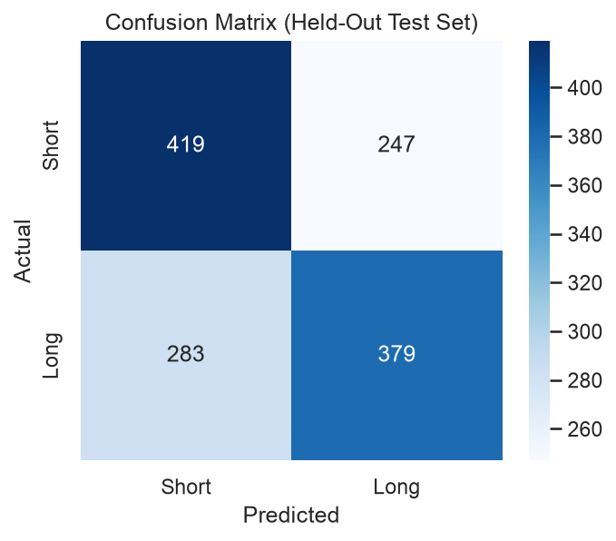

Figure 4: Confusion matrix on the held-out test set.

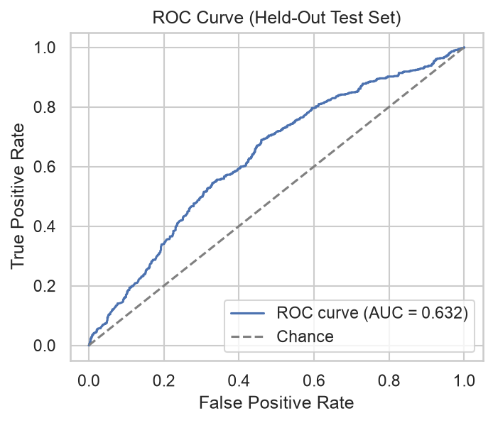

Figure 5: ROC curve on the held-out test set (AUC = 0.632).

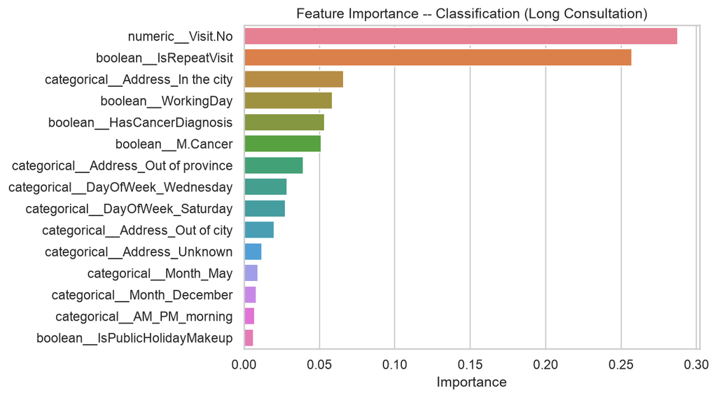

Figure 6: Random Forest feature importances (classification).

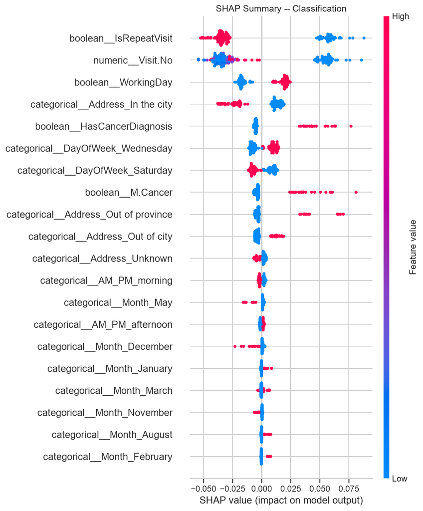

Figure 7: SHAP summary (classification).

An accuracy of 60.1% and ROC-AUC of 0.632 indicate the model captures real, but modest, signal — meaningfully better than the ~50% majority-class baseline, but far from a clinically decisive classifier. The most important predictors by a wide margin are `Visit.No` and `IsRepeatVisit` — together accounting for roughly half of total feature importance — far outweighing cancer-diagnosis flags or calendar features.

## 8 Regression Results: Consultation Duration in Minutes

**Model selection (cross-validated on the training set only):**

Table 5

|  | Model | CV MAE (minutes) |
| --- | --- | --- |
| 0 | Dummy | 4.5361 |
| 1 | Decision Tree | 4.4144 |
| 2 | Ridge | 4.3898 |
| 3 | Xgboost | 4.3880 |
| 4 | Random Forest | 4.3817 |

Random Forest was selected by CV, with `dummy` (predicting the training-set mean/median regardless of features) trailing by about 0.15 minutes MAE — the real signal in this feature set is small in absolute terms.

**Full model-ladder leaderboard, held-out test set:**

Table 6

|  | Model | MAE | RMSE | R2 |
| --- | --- | --- | --- | --- |
| 0 | Xgboost | 4.4034 | 6.0746 | 0.0714 |
| 1 | Random Forest | 4.4129 | 6.0930 | 0.0658 |
| 2 | Ridge | 4.4495 | 6.0965 | 0.0647 |
| 3 | Decision Tree | 4.4732 | 6.1594 | 0.0453 |
| 4 | Dummy | 4.5044 | 6.4523 | -0.0477 |
| 5 | Decision Tree Unconstrained | 5.4198 | 7.3955 | -0.3763 |

Two honest findings here. First, every tuned model clears `dummy` — whose test-set R² is **negative** (worse than always predicting the training mean), which is the expected, correct behaviour of a naive baseline evaluated out-of-sample, not a bug. Second, **`xgboost` edges out Random Forest on this particular held-out test set** (higher R², lower MAE and RMSE), even though CV selected Random Forest during model selection. This is not cherry-picked after the fact — Random Forest remains the deployed model, selected honestly *before* the test set was touched, and the gap between it and XGBoost here is well within the noise expected when several model families land this close in cross-validation. It is reported plainly because the alternative — quietly re-selecting whichever model wins on the test set — is exactly the kind of leakage this project is designed to avoid. The single `decision_tree` lands close to `ridge` and behind both ensembles, the same pattern as classification.

**Overfitting check.** The same unconstrained-vs-tuned decision tree comparison as the classification task, this time on R²:

Table 7

|  | Model | Train R2 | Test R2 | Gap |
| --- | --- | --- | --- | --- |
| 0 | Decision Tree Unconstrained | 0.5875 | -0.3763 | 0.9638 |
| 1 | Decision Tree | 0.1312 | 0.0453 | 0.0860 |
| 2 | Random Forest | 0.1225 | 0.0658 | 0.0567 |

The gap is, if anything, more dramatic here: the unconstrained tree’s training R² of 0.587 collapses to a **negative** test R² of -0.376 — worse than simply predicting the training-set mean for every visit. An unconstrained tree doesn’t just fail to generalise here, it actively memorises noise that actively hurts predictions on new data. Limiting depth during tuning all but closes this gap.

**Selected model’s metrics in isolation** (the numbers used for the figures below):

Table 8

|  | Metric | Value |
| --- | --- | --- |
| 0 | MAE | 4.413 |
| 1 | RMSE | 6.093 |
| 2 | R2 | 0.066 |

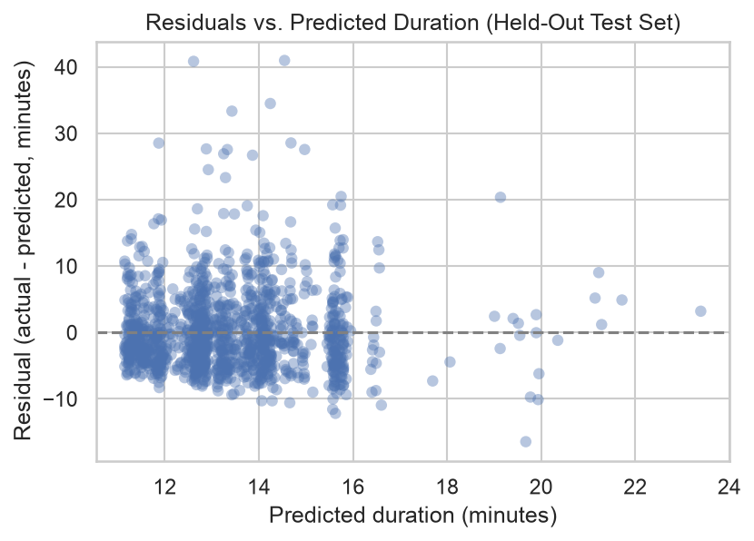

Figure 8: Residuals vs. predicted duration on the held-out test set.

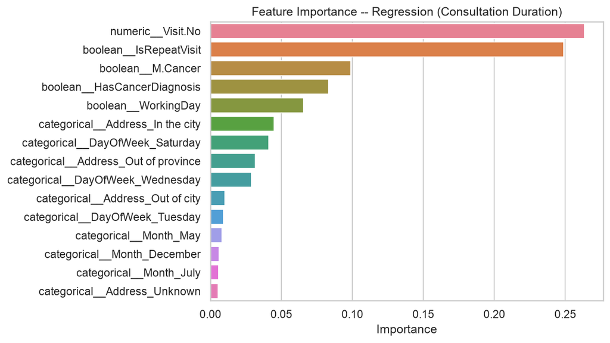

Figure 9: Random Forest feature importances (regression).

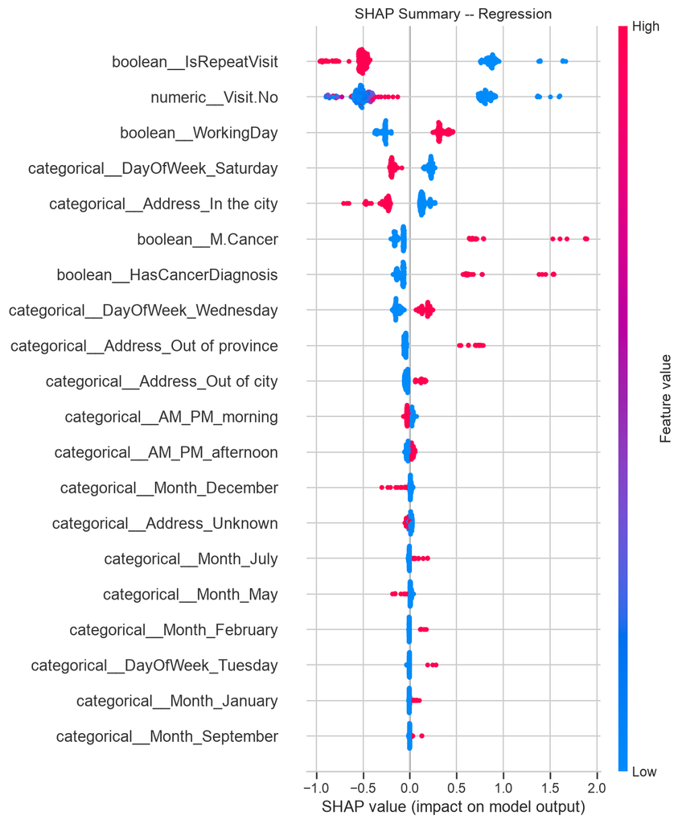

Figure 10: SHAP summary (regression).

The regression result is the most important honest finding in this report. With MAE = 4.41 minutes and **R² = 0.066**, the model explains only a small fraction of the variation in actual consultation duration. Figure 8 shows why: predictions compress into a narrow ~11–24 minute band, while actual durations range from 3 to nearly 58 minutes. Genuinely long consultations are systematically **underestimated** by as much as 40 minutes. The same two features — `Visit.No` and `IsRepeatVisit` — again dominate feature importance.

## 9 Discussion

**What the models tell us for TDABC.** The feature-importance results are, in themselves, a substantive finding for the costing question this project supports: **consultation duration at this clinic is driven primarily by how many times a patient has visited before, not by diagnosis severity or scheduling context.** For TDABC purposes, this suggests that a capacity cost rate built primarily around visit-history segments (new vs. returning patients) would capture more of the real cost-driving variation than one built around calendar or diagnosis segments — though the low R² means any such rate should be treated as a rough planning input, not a precise per-visit cost estimate.

**Why the regression ceiling is low.** The available predictors are exclusively scheduling and demographic fields; none describe the clinical complexity of a given visit (e.g. number of concerns raised, treatment changes, complexity of the case). It is plausible — expected, even — that the majority of variation in a doctor-patient consultation’s length is driven by exactly this kind of clinical content, which this dataset does not capture. The honest conclusion is that scheduling metadata alone is insufficient to predict consultation duration precisely; it can only nudge a scheduling system’s expectations in the right direction on average.

## 10 Conclusion

This project delivers two fully reproducible, leakage-audited models trained on the Hangu outpatient oncology clinic dataset, served through a documented REST API and an interactive web dashboard. The classification model achieves modest but genuine discriminative power (ROC-AUC 0.632); the regression model, while limited in explanatory power (R² 0.066), surfaces a clear and actionable finding: **patient visit history, far more than diagnosis or calendar context, drives consultation duration at this clinic.** For the TDABC application motivating this work, that finding — not the raw predictive accuracy — is the most useful output: it points toward visit-history-based segmentation as the more promising basis for estimating outpatient time-driven cost rates.

## 11 Reproducibility

- Random seed fixed at 42 throughout.
- Library versions: Python 3.14.6, pandas 3.0.3, scikit-learn 1.9.0.
- Full pipeline: `ml/data` → `ml/preprocessing` → `ml/pipelines` → `ml/training` → `ml/evaluation` → `ml/persistence`, each stage covered by its own automated test suite.

## 12 References

Feng, Haolin, Yiwu Jia, Teng Huang, Siyi Zhou, and Hongyi Chen. 2024. “An Adaptive Decision Support System for Outpatient Appointment Scheduling with Heterogeneous Service Times.” *Scientific Reports* 14 (1): 27731. https://doi.org/10.1038/s41598-024-77873-x.

Feng, Haolin, Yiwu Jia, Siyi Zhou, Hongyi Chen, and Teng Huang. 2023. “A Dataset of Service Time and Related Patient Characteristics from an Outpatient Clinic.” *Data* 8 (3): 47. https://doi.org/10.3390/data8030047.

Kaplan, Robert S., and Steven R. Anderson. 2004. *Time-Driven Activity-Based Costing*. Harvard Business Review.